# **Regression Project: Boston House Price Prediction**

# **Marks: 60**

Welcome to the project on regression. We will use the **Boston house price dataset** for this project.

## **Objective**

The problem at hand is to **predict the housing prices of a town or a suburb based on the features of the locality provided to us**. In the process, we need to **identify the most important features affecting the price of the house**. We need to employ techniques of data preprocessing and build a linear regression model that predicts the prices for the unseen data.

## **Dataset**

Each record in the database describes a house in Boston suburb or town. The data was drawn from the Boston Standard Metropolitan Statistical Area (SMSA) in 1970. Detailed attribute information can be found below:

Attribute Information:

- **CRIM:** Per capita crime rate by town
- **ZN:** Proportion of residential land zoned for lots over 25,000 sq.ft.
- **INDUS:** Proportion of non-retail business acres per town
- **CHAS:** Charles River dummy variable (= 1 if tract bounds river; 0 otherwise)
- **NOX:** Nitric Oxide concentration (parts per 10 million)
- **RM:** The average number of rooms per dwelling
- **AGE:** Proportion of owner-occupied units built before 1940
- **DIS:** Weighted distances to five Boston employment centers
- **RAD:** Index of accessibility to radial highways
- **TAX:** Full-value property-tax rate per 10,000 dollars
- **PTRATIO:** Pupil-teacher ratio by town
- **LSTAT:** % lower status of the population
- **MEDV:** Median value of owner-occupied homes in 1000 dollars

## **Importing the necessary libraries**

```python
# Import libraries for data manipulation
import pandas as pd

import numpy as np

# Import libraries for data visualization
import matplotlib.pyplot as plt

import seaborn as sns

from statsmodels.graphics.gofplots import ProbPlot

import pylab

import scipy.stats as stats

# Import libraries for building linear regression model
from statsmodels.formula.api import ols

import statsmodels.api as sm

from sklearn.linear_model import LinearRegression

from statsmodels.stats.diagnostic import het_white

from statsmodels.compat import lzip

from statsmodels.stats.outliers_influence import variance_inflation_factor

from sklearn.model_selection import cross_val_score

import statsmodels.stats.api as sms
from sklearn.metrics import mean_absolute_error

# Import library for preparing data
from sklearn.model_selection import train_test_split

# Import library for data preprocessing
from sklearn.preprocessing import MinMaxScaler

import warnings
warnings.filterwarnings("ignore")
```

### Loading the dataset

```python
df = pd.read_csv("Boston.csv")
display(df.head())
display(df.info())
```

|  | CRIM | ZN | INDUS | CHAS | NOX | RM | AGE | DIS | RAD | TAX | PTRATIO | LSTAT | MEDV |
| --- | --- | --- | --- | --- | --- | --- | --- | --- | --- | --- | --- | --- | --- |
| 0 | 0.00632 | 18.0 | 2.31 | 0 | 0.538 | 6.575 | 65.2 | 4.0900 | 1 | 296 | 15.3 | 4.98 | 24.0 |
| 1 | 0.02731 | 0.0 | 7.07 | 0 | 0.469 | 6.421 | 78.9 | 4.9671 | 2 | 242 | 17.8 | 9.14 | 21.6 |
| 2 | 0.02729 | 0.0 | 7.07 | 0 | 0.469 | 7.185 | 61.1 | 4.9671 | 2 | 242 | 17.8 | 4.03 | 34.7 |
| 3 | 0.03237 | 0.0 | 2.18 | 0 | 0.458 | 6.998 | 45.8 | 6.0622 | 3 | 222 | 18.7 | 2.94 | 33.4 |
| 4 | 0.06905 | 0.0 | 2.18 | 0 | 0.458 | 7.147 | 54.2 | 6.0622 | 3 | 222 | 18.7 | 5.33 | 36.2 |

```
<class 'pandas.core.frame.DataFrame'>
RangeIndex: 506 entries, 0 to 505
Data columns (total 13 columns):
 #   Column   Non-Null Count  Dtype
---  ------   --------------  -----
 0   CRIM     506 non-null    float64
 1   ZN       506 non-null    float64
 2   INDUS    506 non-null    float64
 3   CHAS     506 non-null    int64
 4   NOX      506 non-null    float64
 5   RM       506 non-null    float64
 6   AGE      506 non-null    float64
 7   DIS      506 non-null    float64
 8   RAD      506 non-null    int64
 9   TAX      506 non-null    int64
 10  PTRATIO  506 non-null    float64
 11  LSTAT    506 non-null    float64
 12  MEDV     506 non-null    float64
dtypes: float64(10), int64(3)
memory usage: 51.5 KB
```

```
None
```

As we can observe from above, the Data Set contains 13 different features and 506 observations. I'll study the data more in depth in next section.

## Data Overview

- Observations
- Sanity checks

Let's observe first the composition of the first 10 rows of the data set:

```python
df.head(10)
```

|  | CRIM | ZN | INDUS | CHAS | NOX | RM | AGE | DIS | RAD | TAX | PTRATIO | LSTAT | MEDV |
| --- | --- | --- | --- | --- | --- | --- | --- | --- | --- | --- | --- | --- | --- |
| 0 | 0.00632 | 18.0 | 2.31 | 0 | 0.538 | 6.575 | 65.2 | 4.0900 | 1 | 296 | 15.3 | 4.98 | 24.0 |
| 1 | 0.02731 | 0.0 | 7.07 | 0 | 0.469 | 6.421 | 78.9 | 4.9671 | 2 | 242 | 17.8 | 9.14 | 21.6 |
| 2 | 0.02729 | 0.0 | 7.07 | 0 | 0.469 | 7.185 | 61.1 | 4.9671 | 2 | 242 | 17.8 | 4.03 | 34.7 |
| 3 | 0.03237 | 0.0 | 2.18 | 0 | 0.458 | 6.998 | 45.8 | 6.0622 | 3 | 222 | 18.7 | 2.94 | 33.4 |
| 4 | 0.06905 | 0.0 | 2.18 | 0 | 0.458 | 7.147 | 54.2 | 6.0622 | 3 | 222 | 18.7 | 5.33 | 36.2 |
| 5 | 0.02985 | 0.0 | 2.18 | 0 | 0.458 | 6.430 | 58.7 | 6.0622 | 3 | 222 | 18.7 | 5.21 | 28.7 |
| 6 | 0.08829 | 12.5 | 7.87 | 0 | 0.524 | 6.012 | 66.6 | 5.5605 | 5 | 311 | 15.2 | 12.43 | 22.9 |
| 7 | 0.14455 | 12.5 | 7.87 | 0 | 0.524 | 6.172 | 96.1 | 5.9505 | 5 | 311 | 15.2 | 19.15 | 27.1 |
| 8 | 0.21124 | 12.5 | 7.87 | 0 | 0.524 | 5.631 | 100.0 | 6.0821 | 5 | 311 | 15.2 | 29.93 | 16.5 |
| 9 | 0.17004 | 12.5 | 7.87 | 0 | 0.524 | 6.004 | 85.9 | 6.5921 | 5 | 311 | 15.2 | 17.10 | 18.9 |

It appears that the data loaded correctly, so let's now check the information of each feature:

```python
display(df.info())
df.isnull().sum()
```

```
<class 'pandas.core.frame.DataFrame'>
RangeIndex: 506 entries, 0 to 505
Data columns (total 13 columns):
 #   Column   Non-Null Count  Dtype
---  ------   --------------  -----
 0   CRIM     506 non-null    float64
 1   ZN       506 non-null    float64
 2   INDUS    506 non-null    float64
 3   CHAS     506 non-null    int64
 4   NOX      506 non-null    float64
 5   RM       506 non-null    float64
 6   AGE      506 non-null    float64
 7   DIS      506 non-null    float64
 8   RAD      506 non-null    int64
 9   TAX      506 non-null    int64
 10  PTRATIO  506 non-null    float64
 11  LSTAT    506 non-null    float64
 12  MEDV     506 non-null    float64
dtypes: float64(10), int64(3)
memory usage: 51.5 KB
```

```
None
```

```
CRIM       0
ZN         0
INDUS      0
CHAS       0
NOX        0
RM         0
AGE        0
DIS        0
RAD        0
TAX        0
PTRATIO    0
LSTAT      0
MEDV       0
dtype: int64
```

So we have no missing values, which is great. Now I would like to check if the number in the data set make sense accoridng to the description of the metrics. Let'sget a numeric description of each feature:

```python
df.describe()
```

|  | CRIM | ZN | INDUS | CHAS | NOX | RM | AGE | DIS | RAD | TAX | PTRATIO | LSTAT | MEDV |
| --- | --- | --- | --- | --- | --- | --- | --- | --- | --- | --- | --- | --- | --- |
| count | 506.000000 | 506.000000 | 506.000000 | 506.000000 | 506.000000 | 506.000000 | 506.000000 | 506.000000 | 506.000000 | 506.000000 | 506.000000 | 506.000000 | 506.000000 |
| mean | 3.613524 | 11.363636 | 11.136779 | 0.069170 | 0.554695 | 6.284634 | 68.574901 | 3.795043 | 9.549407 | 408.237154 | 18.455534 | 12.653063 | 22.532806 |
| std | 8.601545 | 23.322453 | 6.860353 | 0.253994 | 0.115878 | 0.702617 | 28.148861 | 2.105710 | 8.707259 | 168.537116 | 2.164946 | 7.141062 | 9.197104 |
| min | 0.006320 | 0.000000 | 0.460000 | 0.000000 | 0.385000 | 3.561000 | 2.900000 | 1.129600 | 1.000000 | 187.000000 | 12.600000 | 1.730000 | 5.000000 |
| 25% | 0.082045 | 0.000000 | 5.190000 | 0.000000 | 0.449000 | 5.885500 | 45.025000 | 2.100175 | 4.000000 | 279.000000 | 17.400000 | 6.950000 | 17.025000 |
| 50% | 0.256510 | 0.000000 | 9.690000 | 0.000000 | 0.538000 | 6.208500 | 77.500000 | 3.207450 | 5.000000 | 330.000000 | 19.050000 | 11.360000 | 21.200000 |
| 75% | 3.677083 | 12.500000 | 18.100000 | 0.000000 | 0.624000 | 6.623500 | 94.075000 | 5.188425 | 24.000000 | 666.000000 | 20.200000 | 16.955000 | 25.000000 |
| max | 88.976200 | 100.000000 | 27.740000 | 1.000000 | 0.871000 | 8.780000 | 100.000000 | 12.126500 | 24.000000 | 711.000000 | 22.000000 | 37.970000 | 50.000000 |

We can observe that those varaibles that are proportions, `ZN`, `INDUX` and `AGE`, all have values that are in the required range between 0 and 100. Furthermore, the dummy variable `CHAS` is also in the desired range 0 and 1. All columns are numeric, which goes accordingly to the variables description,

## Exploratory Data Analysis (EDA)

- EDA is an important part of any project involving data.
- It is important to investigate and understand the data better before building a model with it.
- A few questions have been mentioned below which will help you approach the analysis in the right manner and generate insights from the data.
- A thorough analysis of the data, in addition to the questions mentioned below, should be done.

**Questions:**

1. What does the distribution of 'MEDV' look like?
2. What can we infer form the correlation heatmap? Is there correlation between the dependent and independent variables?
3. What are all the inferences that can be found by doing univariate analysis for different variables?
4. Do bivariate analysis to visualize the relationship between the features having significant correlations (>= 0.7 or <= -0.7)

### Univariate analysis

Let's take a look at the distibutions of each one of the variables in the data set in order to explore its composition.

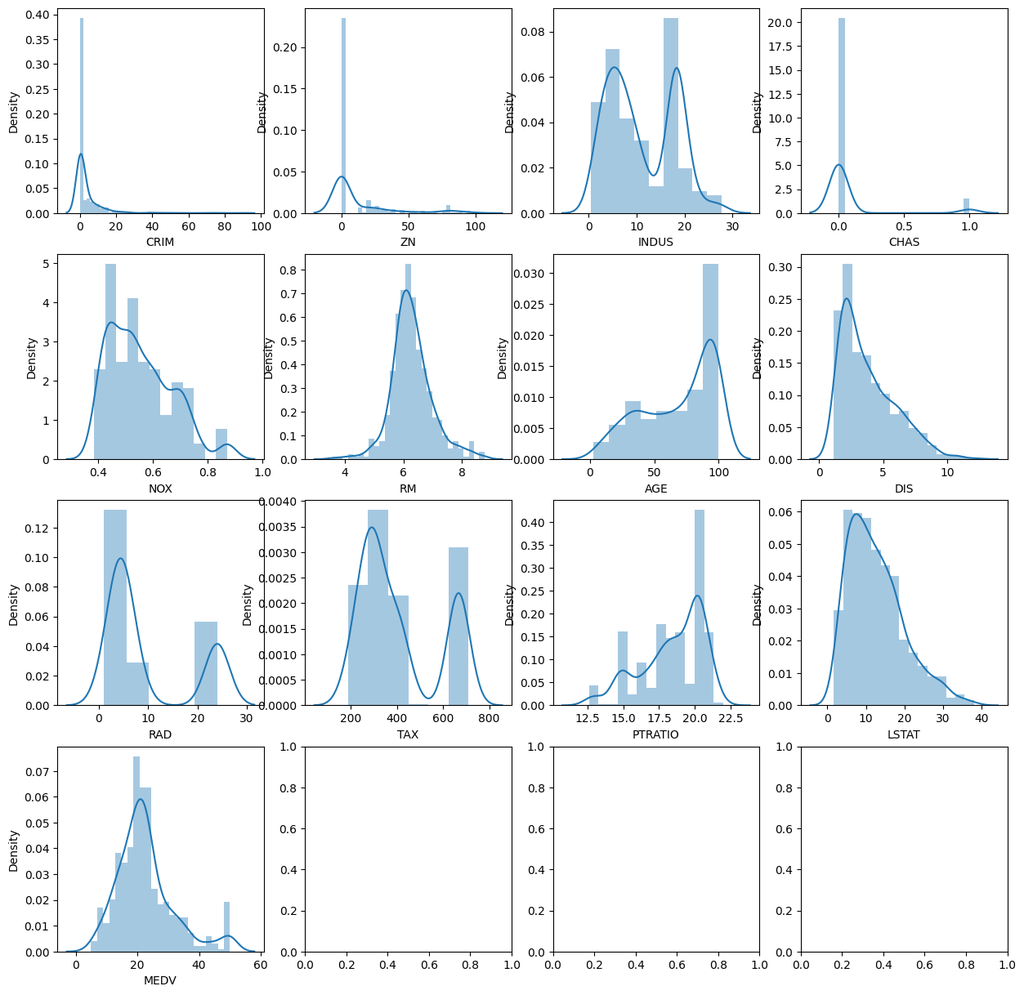

```python
#Set Grid Size
n_rows=4
n_cols=4
# Create the subplots
fig, axes = plt.subplots(nrows=n_rows, ncols=n_cols)
fig.set_size_inches(15, 15)
for i, column in enumerate(df.columns):
    sns.distplot(df[column],ax=axes[i//n_cols,i%n_cols])
```

**Observations:**

- The target variable `MEDV` resembles a normal distibution, although somewhat skewed to the right.
- `CRIM` and `ZN` are highly skewed to the right. This can also be seen in the table used previously, by noticing the difference between their measures of centrality and their maximum value.
- `INDUS`, `RAD` and `TAX` are multi-modal distributions, meaning that they see a high concentration of observations at two different locations.

In order to better visualize the distribution of the dependent variable, we can apply a logaritmic transformation to ease the skewness.

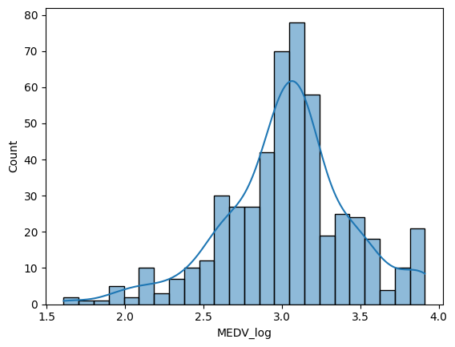

```python
df['MEDV_log'] = np.log(df['MEDV'])
sns.histplot(data = df, x = 'MEDV_log', kde = True)
```

Once transformed, we can see that `MEDV_log` is more normal looking.

### Bivariate analysis

Since we are creating a linear regression model, it is vital to understand the realtionship between the variables that we are using, especially between the response variable and the rest.

A simple way to see this is by creating a heat map that also shows the coefficient of correlation between our variables:

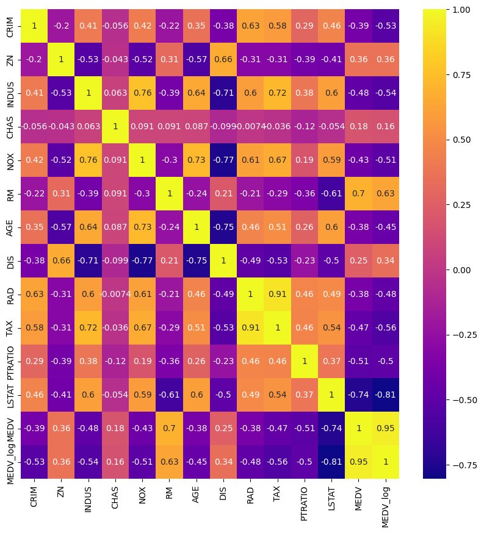

```python
plt.figure(figsize=(10,10))
sns.heatmap(df.corr(),annot=True, cmap='plasma')
```

**Observations:**

- `MEDV` is highly negative correlated with `LSTAT` and highly positive correlated with `RM`, which both make sense conceptually.
- All other features seem to have a medium correlation witht he response variable, except for `DIS`, `CHAS` and `ZN` who appear to have a weak correlation.

Now, as requested, we shall visualize the relationshp between varaibles with significant correlation (>= 0.7 or <= -0.7):

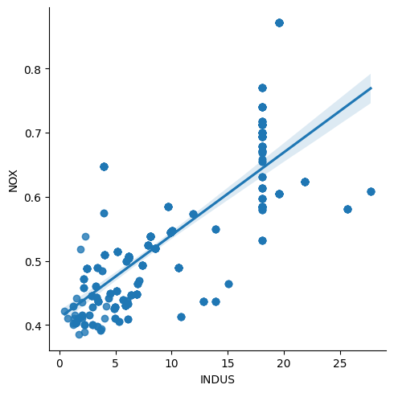

```python
# INDUS & NOX
plt.figure(figsize = (6, 6))

sns.lmplot(x = 'INDUS', y = 'NOX', data = df)

plt.show()
```

**Observations:**

- An increase in `INDUS` appears to be related to an increase in `NOX`. This makes theorical sense, since more business could mean more pollution.

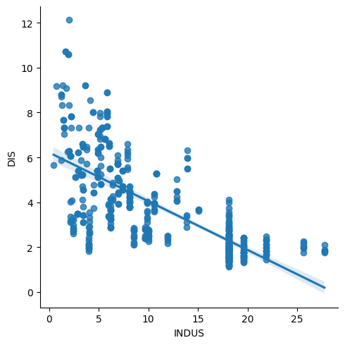

```python
# INDUS & DIS
plt.figure(figsize = (6, 6))

sns.lmplot(x = 'INDUS', y = 'DIS', data = df)

plt.show()
```

**Observations:**

- An increase in `INDUS` appears to be related to an decrease in `DIS`. This could be just a coinicidence, since there is no true-world relationship. There could be also a hidden variable that causes the relation.

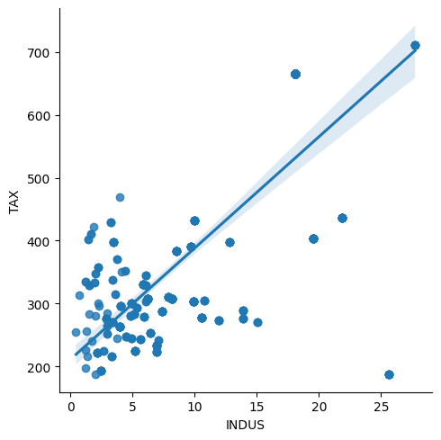

```python
# INDUS & TAX
plt.figure(figsize = (6, 6))

sns.lmplot(x = 'INDUS', y = 'TAX', data = df)

plt.show()
```

**Observations:**

- An increase in `INDUS` appears to be related to an increase in `TAX`. This realtionship could be a result of a hidden variable or just the fiscal system for busniess districts.
- More likely, this high correlation is due to the outliers present in the data.

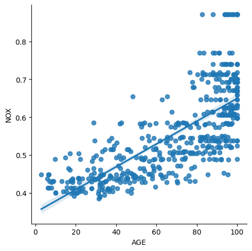

```python
# AGE & NOX
plt.figure(figsize = (6, 6))

sns.lmplot(x = 'AGE', y = 'NOX', data = df)

plt.show()
```

**Observations:**

- An increase in `AGE` appears to be related to an increase in `NOX`.

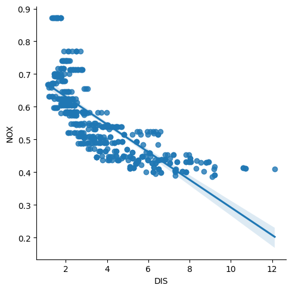

```python
# DIS & NOX
plt.figure(figsize = (6, 6))

sns.lmplot(x = 'DIS', y = 'NOX', data = df)

plt.show()
```

**Observations:**

- An increase in `DIS` appears to be related to an decrease in `NOX`. This could be just a coinicidence, since there is no true-world relationship. There could be also a hidden variable that causes the relation.

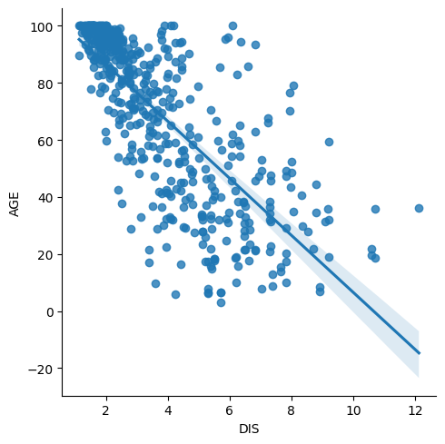

```python
# DIS & NOX
plt.figure(figsize = (6, 6))

sns.lmplot(x = 'DIS', y = 'AGE', data = df)

plt.show()
```

**Observations:**

- An increase in `DIS` appears to be related to an decrease in `AGE`. It is possible that the employment centers are located where a lot of units were built prior to 1940.

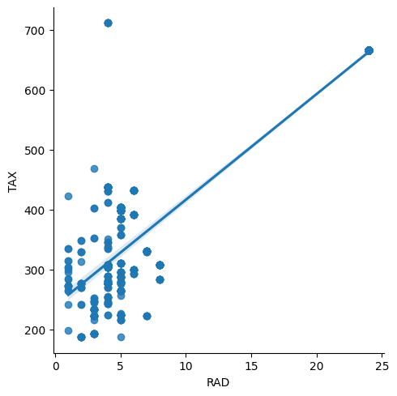

```python
# RAD& TAX
plt.figure(figsize = (6, 6))

sns.lmplot(x = 'RAD', y = 'TAX', data = df)

plt.show()
```

**Observations:**

- An increase in `RAD` appears to be related to an increase in `TAX`.
- More likely, this high correlation is due to the outliers present in the data.

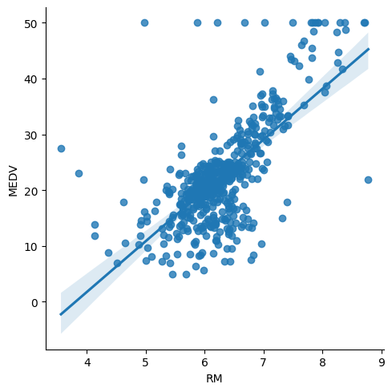

```python
# RM & MEDV
plt.figure(figsize = (6, 6))

sns.lmplot(x = 'RM', y = 'MEDV', data = df)

plt.show()
```

**Observations:**

- An increase in `RM` appears to be related to an increase in `MEDV`.
- This makes sense, since more rooms are usually associated with a higher price. Nevertheless, it is not the only factor when it comes to price.

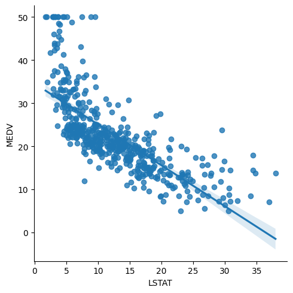

```python
# LSTAT & MEDV
plt.figure(figsize = (6, 6))

sns.lmplot(x = 'LSTAT', y = 'MEDV', data = df)

plt.show()
```

**Observations:**

- An increase in `LSTAT` appears to be related to an decrease in `MEDV`.
- This makes sense, since more lower status population would not be able to affor expensive homes.

**OVER ALL OBSERVATIONS:**

- Both `STAT` and `RM` have a strong correaltion withthe response variable.
- Several other variables have a strong correlation between each other, which is a sign of multicolinearity. We should be aware of this while training the model.

## Data Preprocessing

- Missing value treatment
- Log transformation of dependent variable if skewed
- Feature engineering (if needed)
- Outlier detection and treatment (if needed)
- Preparing data for modeling
- Any other preprocessing steps (if needed)

### **Splitting data set:**

It is important to have a training and test set for the model, that is what we will do next:

```python
# Separate the dependent variable
Y = df['MEDV_log']

X = df.drop(columns = {'MEDV', 'MEDV_log'})

# Add the intercept term
X = sm.add_constant(X)

# splitting the data in 70/30
X_train, X_test, y_train, y_test = train_test_split(X, Y, test_size = 0.30, random_state = 1)
```

### Multicolinearity

Let's now check for multicolinearity in the training set. We can use the Variance Infaltion factor, which basically tells us how much the variance of an estimated regression coefficient increases if your predictors are correlated. A high VIF indicates high multicollinearity.

```python
vif_data = pd.DataFrame() #Create new empty Df
vif_data["Variable"] = X_train.columns #Assign values
vif_data["VIF"] = [variance_inflation_factor(X_train.values, i) for i in range(X_train.shape[1])] #Perform test

print(vif_data)
```

```
   Variable         VIF
0     const  535.372593
1      CRIM    1.924114
2        ZN    2.743574
3     INDUS    3.999538
4      CHAS    1.076564
5       NOX    4.396157
6        RM    1.860950
7       AGE    3.150170
8       DIS    4.355469
9       RAD    8.345247
10      TAX   10.191941
11  PTRATIO    1.943409
12    LSTAT    2.861881
```

We can observe that `TAX` and `RAD` show a high VIF factor. Since `TAX` is higher, we can remove it and perform the test again.

```python
X_train_2 = X_train.drop('TAX', axis=1) #Drop the column

vif_data = pd.DataFrame() #Create new empty Df
vif_data["Variable"] = X_train_2.columns #Assign values
vif_data["VIF"] = [variance_inflation_factor(X_train_2.values, i) for i in range(X_train_2.shape[1])] #Perform test

print(vif_data)
```

```
   Variable         VIF
0     const  532.025529
1      CRIM    1.923159
2        ZN    2.483399
3     INDUS    3.270983
4      CHAS    1.050708
5       NOX    4.361847
6        RM    1.857918
7       AGE    3.149005
8       DIS    4.333734
9       RAD    2.942862
10  PTRATIO    1.909750
11    LSTAT    2.860251
```

That did the trick, we can proceed now.

```python
#Just making sure we have the correct training data
X_train = X_train.drop('TAX', axis=1) #Drop the column
```

## Model Building - Linear Regression

```python
model1 = sm.OLS(y_train,X_train).fit()
model1.summary()
```

OLS Regression Results

| Dep. Variable: | MEDV_log | R-squared: | 0.769 |
| --- | --- | --- | --- |
| Model: | OLS | Adj. R-squared: | 0.761 |
| Method: | Least Squares | F-statistic: | 103.3 |
| Date: | Fri, 24 Nov 2023 | Prob (F-statistic): | 1.40e-101 |
| Time: | 21:06:52 | Log-Likelihood: | 76.596 |
| No. Observations: | 354 | AIC: | -129.2 |
| Df Residuals: | 342 | BIC: | -82.76 |
| Df Model: | 11 |  |  |
| Covariance Type: | nonrobust |  |  |

|  | coef | std err | t | P>\|t\| | [0.025 | 0.975] |
| --- | --- | --- | --- | --- | --- | --- |
| const | 4.6324 | 0.243 | 19.057 | 0.000 | 4.154 | 5.111 |
| CRIM | -0.0128 | 0.002 | -7.445 | 0.000 | -0.016 | -0.009 |
| ZN | 0.0010 | 0.001 | 1.425 | 0.155 | -0.000 | 0.002 |
| INDUS | -0.0004 | 0.003 | -0.148 | 0.883 | -0.006 | 0.005 |
| CHAS | 0.1196 | 0.039 | 3.082 | 0.002 | 0.043 | 0.196 |
| NOX | -1.0598 | 0.187 | -5.675 | 0.000 | -1.427 | -0.692 |
| RM | 0.0532 | 0.021 | 2.560 | 0.011 | 0.012 | 0.094 |
| AGE | 0.0003 | 0.001 | 0.461 | 0.645 | -0.001 | 0.002 |
| DIS | -0.0503 | 0.010 | -4.894 | 0.000 | -0.071 | -0.030 |
| RAD | 0.0076 | 0.002 | 3.699 | 0.000 | 0.004 | 0.012 |
| PTRATIO | -0.0452 | 0.007 | -6.659 | 0.000 | -0.059 | -0.032 |
| LSTAT | -0.0298 | 0.002 | -12.134 | 0.000 | -0.035 | -0.025 |

| Omnibus: | 30.699 | Durbin-Watson: | 1.923 |
| --- | --- | --- | --- |
| Prob(Omnibus): | 0.000 | Jarque-Bera (JB): | 83.718 |
| Skew: | 0.372 | Prob(JB): | 6.62e-19 |
| Kurtosis: | 5.263 | Cond. No. | 2.09e+03 |

Notes:  
[1] Standard Errors assume that the covariance matrix of the errors is correctly specified.  
[2] The condition number is large, 2.09e+03. This might indicate that there are  
strong multicollinearity or other numerical problems.

```python
X_train = X_train.drop(['ZN','INDUS','AGE'], axis=1) #Drop the columns
#Train again
model2 = sm.OLS(y_train,X_train).fit()
model2.summary()
```

OLS Regression Results

| Dep. Variable: | MEDV_log | R-squared: | 0.767 |
| --- | --- | --- | --- |
| Model: | OLS | Adj. R-squared: | 0.762 |
| Method: | Least Squares | F-statistic: | 142.1 |
| Date: | Fri, 24 Nov 2023 | Prob (F-statistic): | 2.61e-104 |
| Time: | 21:37:50 | Log-Likelihood: | 75.486 |
| No. Observations: | 354 | AIC: | -133.0 |
| Df Residuals: | 345 | BIC: | -98.15 |
| Df Model: | 8 |  |  |
| Covariance Type: | nonrobust |  |  |

|  | coef | std err | t | P>\|t\| | [0.025 | 0.975] |
| --- | --- | --- | --- | --- | --- | --- |
| const | 4.6494 | 0.242 | 19.242 | 0.000 | 4.174 | 5.125 |
| CRIM | -0.0125 | 0.002 | -7.349 | 0.000 | -0.016 | -0.009 |
| CHAS | 0.1198 | 0.039 | 3.093 | 0.002 | 0.044 | 0.196 |
| NOX | -1.0562 | 0.168 | -6.296 | 0.000 | -1.386 | -0.726 |
| RM | 0.0589 | 0.020 | 2.928 | 0.004 | 0.019 | 0.098 |
| DIS | -0.0441 | 0.008 | -5.561 | 0.000 | -0.060 | -0.028 |
| RAD | 0.0078 | 0.002 | 3.890 | 0.000 | 0.004 | 0.012 |
| PTRATIO | -0.0485 | 0.006 | -7.832 | 0.000 | -0.061 | -0.036 |
| LSTAT | -0.0293 | 0.002 | -12.949 | 0.000 | -0.034 | -0.025 |

| Omnibus: | 32.514 | Durbin-Watson: | 1.925 |
| --- | --- | --- | --- |
| Prob(Omnibus): | 0.000 | Jarque-Bera (JB): | 87.354 |
| Skew: | 0.408 | Prob(JB): | 1.07e-19 |
| Kurtosis: | 5.293 | Cond. No. | 690. |

Notes:  
[1] Standard Errors assume that the covariance matrix of the errors is correctly specified.

## Model Performance Check

1. How does the model is performing? Check using Rsquared, RSME, MAE, MAPE
2. Is there multicollinearity? Check using VIF
3. How does the model is performing after cross validation?

```python
rmse = np.sqrt(np.mean((y_train - model2.predict(X_train)) ** 2)) #RMSE
print('RSME: ', rmse)

mae = mean_absolute_error(y_train, model2.predict(X_train)) #MAE
print('MAE: ',mae)

mape = np.mean(np.abs((y_train - model2.predict(X_train)) / y_train)) * 100  #MAPE
print('MAPE: ',mape)
```

```
RSME:  0.19550370967293879
MAE:  0.14368596074360657
MAPE:  4.9818125047542825
```

In general, this metrics tell us that the model is performing well, telling us that the model is predicitng just a 4.98% error in each observation.

## Checking Linear Regression Assumptions

- In order to make statistical inferences from a linear regression model, it is important to ensure that the assumptions of linear regression are satisfied.

### 1. Mean residuals equal to zero

```python
residuals = model2.resid

np.mean(residuals)
```

```
-2.7379228827620387e-15
```

The mean of the residuals should be zero for our model. As we can see above, this is satisfied since we get a number really close to zero.

### 2. No heteroscedasticity

This means that the residuals of the model should be spred out evenly, so there is no tendency with respect certain values.

There are several ways to test this, even visually, but is better to use a hypothesis test:

- Null H: Residuals are homoscedastic (desireable)
- Alternative H: Residuals are heteroscedastic (undesirable)

```python
test = sms.het_goldfeldquandt(model2.resid, X_train) ## Test
print('P-value of test: ',test[1])
```

```
P-value of test:  0.3019012006766869
```

We should see this graphically as well:

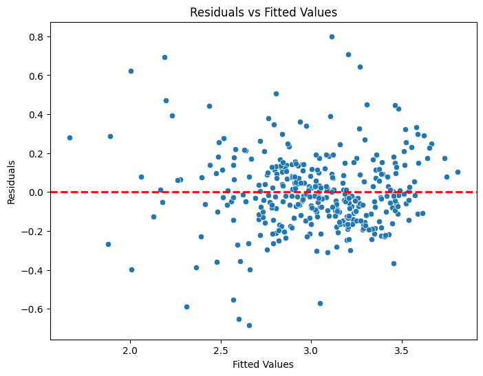

```python
plt.figure(figsize=(8, 6))
sns.scatterplot(x=model2.fittedvalues, y=model2.resid)
plt.axhline(y=0, color='r', linestyle='--', linewidth=2)  # Add a horizontal line at y=0
plt.title('Residuals vs Fitted Values')
plt.xlabel('Fitted Values')
plt.ylabel('Residuals')
plt.show()
```

### 3. Lineality of variables

In the previous graph we can observe that the fitted values appear randomly and uniformlt scattered, which demostrates linearity of the variables. If they weren't, the values would create a clear pattern.

### 4. Normality of error terms

The residuals should be normally distributed.

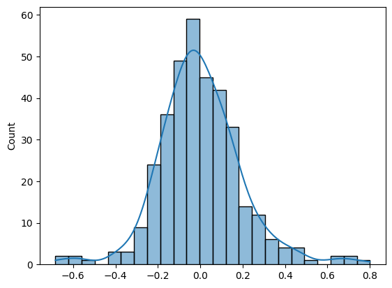

```python
sns.histplot(model2.resid,kde=True)
```

It appears that they are normally distributed. Lets do a QQ plot to make sure:

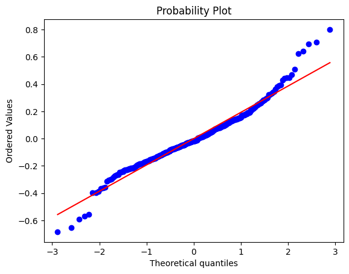

```python
stats.probplot(model2.resid, dist = "norm", plot = pylab)

plt.show()
```

They no longer appear to be normally distributed.

```python
jb_test_statistic, jb_p_value, _, _ = sm.stats.stattools.jarque_bera(model2.resid)

print(f"Jarque-Bera Test Statistic: {jb_test_statistic:.4f}")
print(f"P-value for Jarque-Bera test: {jb_p_value:.4f}")

# Interpret the results
if jb_p_value < 0.05:
    print("The test suggests that the residuals are not normally distributed.")
else:
    print("The test does not provide strong evidence against the normality of residuals.")
```

```
Jarque-Bera Test Statistic: 87.3544
P-value for Jarque-Bera test: 0.0000
The test suggests that the residuals are not normally distributed.
```

## Final Model

Let's now get some cross validation to get a final model for prediction and insights.

First, let's define some metric and model performance functions to make the code run a bit smoother, then we will run the model:

```python
# RMSE
def rmse(predictions, targets):
    return np.sqrt(((targets - predictions) ** 2).mean())


# MAPE
def mape(predictions, targets):
    return np.mean(np.abs((targets - predictions)) / targets) * 100


# MAE
def mae(predictions, targets):
    return np.mean(np.abs((targets - predictions)))

# Model Performance on test and train data
def model_pref(olsmodel, x_train, x_test):

    # In-sample Prediction
    y_pred_train = olsmodel.predict(x_train)
    y_observed_train = y_train

    # Prediction on test data
    y_pred_test = olsmodel.predict(x_test)
    y_observed_test = y_test

    print(
        pd.DataFrame(
            {
                "Data": ["Train", "Test"],
                "RMSE": [
                    rmse(y_pred_train, y_observed_train),
                    rmse(y_pred_test, y_observed_test),
                ],
                "MAE": [
                    mae(y_pred_train, y_observed_train),
                    mae(y_pred_test, y_observed_test),
                ],
                "MAPE": [
                    mape(y_pred_train, y_observed_train),
                    mape(y_pred_test, y_observed_test),
                ],
            }
        )
    )
```

```python
#Make the test data match the train data
X_test = X_test.drop(['TAX','ZN','INDUS','AGE'], axis=1) #Drop the columns
# Checking model performance
model_pref(model2, X_train, X_test)
```

```
    Data      RMSE       MAE      MAPE
0  Train  0.195504  0.143686  4.981813
1   Test  0.198045  0.151284  5.257965
```

We can see that out model is pretty consistent between the train and test data, which tells us that we have done a good job.

Now let's make sure of that by applying cross validation:

```python
# Build the regression model and cross-validate
linearregression = LinearRegression()

cv_Score11 = cross_val_score(linearregression, X_train, y_train, cv = 10)
cv_Score12 = cross_val_score(linearregression, X_train, y_train, cv = 10,
                             scoring = 'neg_mean_squared_error')


print("RSquared: %0.3f (+/- %0.3f)" % (cv_Score11.mean(), cv_Score11.std() * 2))
print("Mean Squared Error: %0.3f (+/- %0.3f)" % (-1*cv_Score12.mean(), cv_Score12.std() * 2))
```

```
RSquared: 0.729 (+/- 0.232)
Mean Squared Error: 0.041 (+/- 0.023)
```

With this result we can see that, by using 10 different combination of subsets for trainign and testing data. Now, we can generalize the results of the model trough different samples.

We can see that the R squared value ranges from 0.497 to 0.961, a long stretch, but provides a better understanding of the capabilities of our model. The same for the Mean Squared Error

Let's take a final look at the model parameters:

```python
coef = model2.params

pd.DataFrame({'Feature' : coef.index, 'Coefs' : coef.values})
```

|  | Feature | Coefs |
| --- | --- | --- |
| 0 | const | 4.649386 |
| 1 | CRIM | -0.012500 |
| 2 | CHAS | 0.119773 |
| 3 | NOX | -1.056225 |
| 4 | RM | 0.058907 |
| 5 | DIS | -0.044069 |
| 6 | RAD | 0.007848 |
| 7 | PTRATIO | -0.048504 |
| 8 | LSTAT | -0.029277 |